2022-08-15

# Notes

These models are very similar to the original sets of models with two exceptions:

1. The outcome has now been standardized prior to fitting. Now we interpret the coefficients in the model as standard deviation changes in thickness from change in outcome
2. Laterality is no longer a random effect. We did not specify this in our research statement, but after standardizing the response variable, the two groups became virtually indistinguishable and the model became unstable. Keeping laterality as a fixed effect seems to have helped with this, but as you’ll see, the effect of laterality is almost nearly zero.

Lastly, though the coefficients have largely changed, for most models and most terms (besides the intercept), the associated $p$-value has not changed. This should give us some confidence in both the model response and the standard error.

# Summaries (standardized)

These models are for the analysis for hypothesis 1 and 2. That is, linear mixed effects models with ROI thickness as dependent, and age, sex, race/ethnicity, SES, term/pretern, and interaction as independent. Random intercepts for site, but no longer for laterality

Each tab is one of the SES metrics, containing model summaries for all brain regions (standardized ADI, combined education, income to needs ratio)

## ADI

Plot of standardized ADI by preterm status

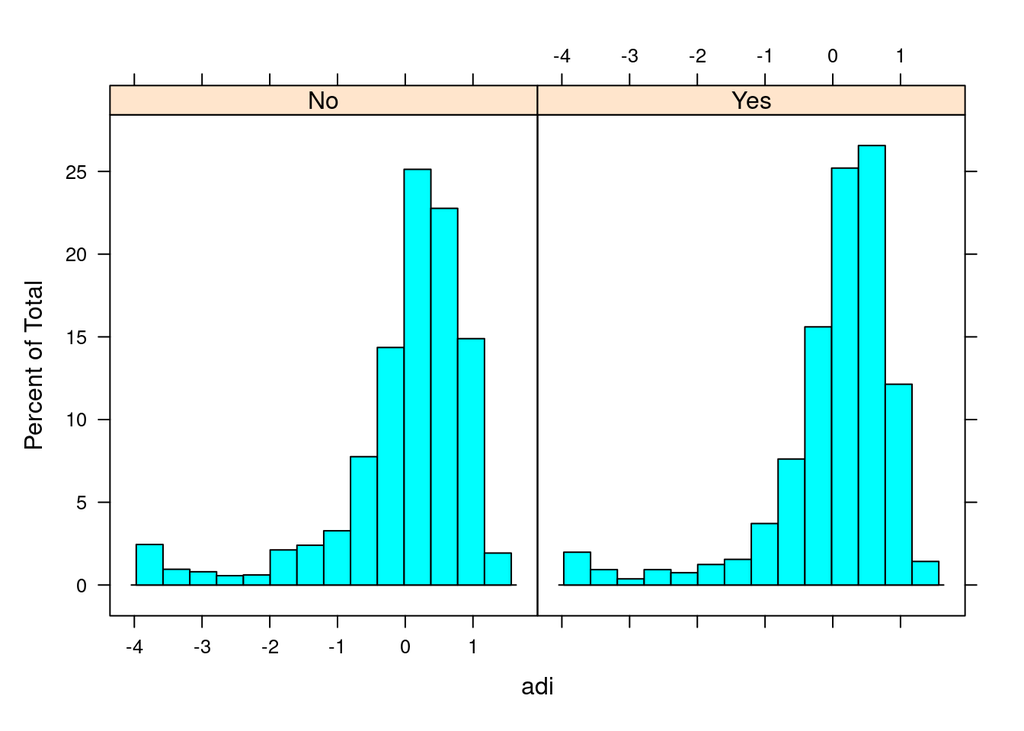

```
## [[1]]
##
##
## Table: smri_thick_cort.destrieux_g.front.inf.opercular
##
## |                       | Estimate| Std. Error|    95%L|    95%U|  p-val|
## |:----------------------|--------:|----------:|-------:|-------:|------:|
## |(Intercept)            |   0.1568|     0.1581| -0.1530|  0.4667| 0.3217|
## |race_ethnicityBlack    |   0.3640|     0.0762|  0.2146|  0.5135| 0.0000|
## |race_ethnicityHispanic |   0.1131|     0.0759| -0.0357|  0.2618| 0.1363|
## |race_ethnicityOther    |   0.1763|     0.0757|  0.0280|  0.3247| 0.0198|
## |race_ethnicityWhite    |   0.1727|     0.0735|  0.0287|  0.3168| 0.0188|
## |femaleyes              |   0.1222|     0.0146|  0.0937|  0.1507| 0.0000|
## |premature              |  -0.0009|     0.0196| -0.0394|  0.0376| 0.9626|
## |adi                    |  -0.0205|     0.0097| -0.0396| -0.0014| 0.0354|
## |age                    |  -0.0037|     0.0010| -0.0056| -0.0017| 0.0002|
## |lateralityrh           |   0.0000|     0.0145| -0.0284|  0.0284| 1.0000|
## |premature:adi          |   0.0600|     0.0194|  0.0219|  0.0981| 0.0020|
##
## [[2]]
##
##
## Table: smri_thick_cort.destrieux_g.front.inf.orbital
##
## |                       | Estimate| Std. Error|    95%L|    95%U|  p-val|
## |:----------------------|--------:|----------:|-------:|-------:|------:|
## |(Intercept)            |   0.3874|     0.1507|  0.0920|  0.6828| 0.0102|
## |race_ethnicityBlack    |   0.1481|     0.0794| -0.0076|  0.3038| 0.0622|
## |race_ethnicityHispanic |   0.1368|     0.0791| -0.0182|  0.2918| 0.0837|
## |race_ethnicityOther    |   0.1924|     0.0789|  0.0379|  0.3470| 0.0147|
## |race_ethnicityWhite    |   0.2515|     0.0766|  0.1014|  0.4015| 0.0010|
## |femaleyes              |   0.1107|     0.0152|  0.0810|  0.1405| 0.0000|
## |premature              |  -0.0627|     0.0204| -0.1027| -0.0226| 0.0022|
## |adi                    |  -0.0379|     0.0101| -0.0577| -0.0182| 0.0002|
## |age                    |  -0.0054|     0.0010| -0.0075| -0.0034| 0.0000|
## |lateralityrh           |   0.0000|     0.0151| -0.0297|  0.0297| 1.0000|
## |premature:adi          |   0.0281|     0.0203| -0.0116|  0.0678| 0.1651|
##
## [[3]]
##
```

[output cut: 96 more lines]

```
## Table: smri_thick_cort.destrieux_s.temporal.transverse
##
## |                       | Estimate| Std. Error|    95%L|    95%U|  p-val|
## |:----------------------|--------:|----------:|-------:|-------:|------:|
## |(Intercept)            |   0.3747|     0.1472|  0.0863|  0.6631| 0.0109|
## |race_ethnicityBlack    |  -0.1117|     0.0800| -0.2685|  0.0452| 0.1629|
## |race_ethnicityHispanic |  -0.0458|     0.0797| -0.2019|  0.1104| 0.5658|
## |race_ethnicityOther    |  -0.0172|     0.0795| -0.1730|  0.1386| 0.8286|
## |race_ethnicityWhite    |   0.0200|     0.0771| -0.1310|  0.1711| 0.7948|
## |femaleyes              |   0.2321|     0.0153|  0.2021|  0.2622| 0.0000|
## |premature              |  -0.0159|     0.0206| -0.0562|  0.0243| 0.4380|
## |adi                    |  -0.0259|     0.0099| -0.0454| -0.0064| 0.0092|
## |age                    |  -0.0040|     0.0010| -0.0060| -0.0019| 0.0001|
## |lateralityrh           |   0.0000|     0.0153| -0.0300|  0.0300| 1.0000|
## |premature:adi          |   0.0384|     0.0205| -0.0017|  0.0785| 0.0607|
```

## Parent Education

Histogram of averaged parent education by preterm status

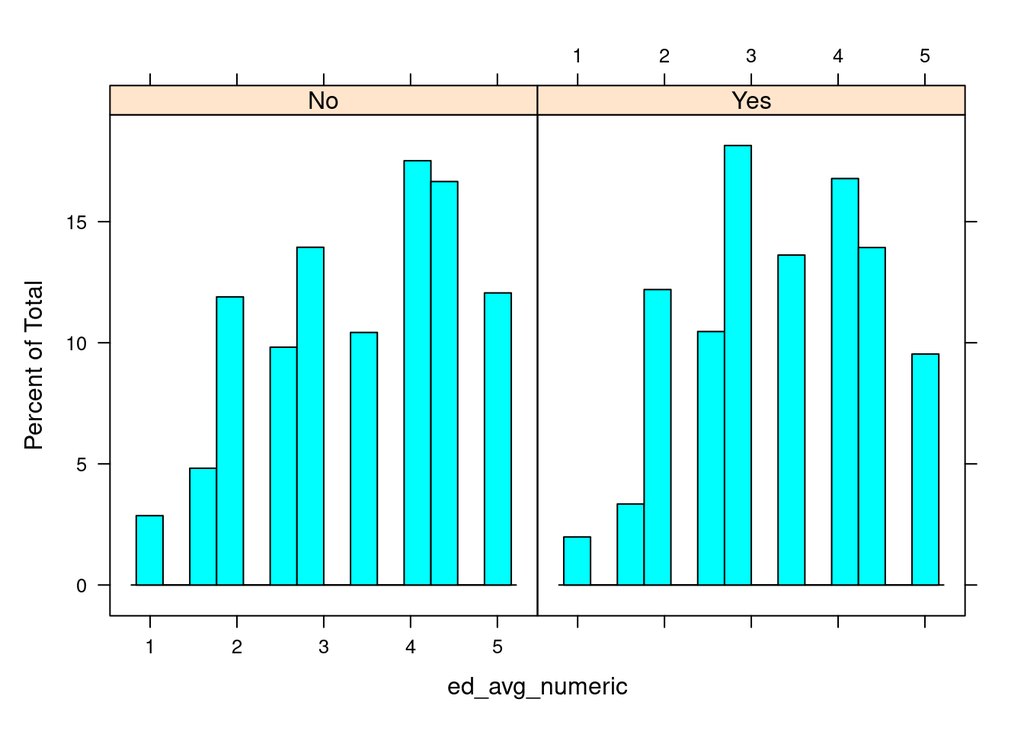

Here, we are using `ed_avg_numeric`, a numeric average of the attained education of parent and partner

Correlation between parent and partner ed is 0.5137

```
## [[1]]
##
##
## Table: smri_thick_cort.destrieux_g.front.inf.opercular
##
## |                         | Estimate| Std. Error|    95%L|    95%U|  p-val|
## |:------------------------|--------:|----------:|-------:|-------:|------:|
## |(Intercept)              |   0.0864|     0.1615| -0.2303|  0.4030| 0.5932|
## |race_ethnicityBlack      |   0.3705|     0.0768|  0.2199|  0.5210| 0.0000|
## |race_ethnicityHispanic   |   0.1160|     0.0762| -0.0333|  0.2654| 0.1279|
## |race_ethnicityOther      |   0.1764|     0.0758|  0.0279|  0.3249| 0.0199|
## |race_ethnicityWhite      |   0.1709|     0.0735|  0.0268|  0.3150| 0.0201|
## |femaleyes                |   0.1230|     0.0146|  0.0944|  0.1515| 0.0000|
## |premature                |   0.1068|     0.0627| -0.0160|  0.2297| 0.0883|
## |ed_avg_numeric           |   0.0173|     0.0082|  0.0013|  0.0334| 0.0344|
## |age                      |  -0.0036|     0.0010| -0.0055| -0.0016| 0.0003|
## |lateralityrh             |   0.0000|     0.0145| -0.0284|  0.0284| 1.0000|
## |premature:ed_avg_numeric |  -0.0315|     0.0177| -0.0661|  0.0032| 0.0749|
##
## [[2]]
##
##
## Table: smri_thick_cort.destrieux_g.front.inf.orbital
##
## |                         | Estimate| Std. Error|    95%L|    95%U|  p-val|
## |:------------------------|--------:|----------:|-------:|-------:|------:|
## |(Intercept)              |   0.2925|     0.1547| -0.0106|  0.5956| 0.0586|
## |race_ethnicityBlack      |   0.1536|     0.0800| -0.0032|  0.3104| 0.0549|
## |race_ethnicityHispanic   |   0.1399|     0.0794| -0.0157|  0.2955| 0.0781|
## |race_ethnicityOther      |   0.1925|     0.0789|  0.0378|  0.3472| 0.0148|
## |race_ethnicityWhite      |   0.2509|     0.0766|  0.1008|  0.4009| 0.0011|
## |femaleyes                |   0.1112|     0.0152|  0.0815|  0.1410| 0.0000|
## |premature                |   0.0032|     0.0654| -0.1249|  0.1313| 0.9610|
## |ed_avg_numeric           |   0.0245|     0.0085|  0.0078|  0.0413| 0.0041|
## |age                      |  -0.0053|     0.0010| -0.0073| -0.0033| 0.0000|
## |lateralityrh             |   0.0000|     0.0151| -0.0297|  0.0297| 1.0000|
## |premature:ed_avg_numeric |  -0.0193|     0.0184| -0.0554|  0.0169| 0.2957|
##
## [[3]]
##
```

[output cut: 96 more lines]

```
## Table: smri_thick_cort.destrieux_s.temporal.transverse
##
## |                         | Estimate| Std. Error|    95%L|    95%U|  p-val|
## |:------------------------|--------:|----------:|-------:|-------:|------:|
## |(Intercept)              |   0.3138|     0.1513|  0.0173|  0.6103| 0.0381|
## |race_ethnicityBlack      |  -0.1130|     0.0804| -0.2707|  0.0446| 0.1600|
## |race_ethnicityHispanic   |  -0.0482|     0.0799| -0.2048|  0.1084| 0.5463|
## |race_ethnicityOther      |  -0.0210|     0.0795| -0.1768|  0.1348| 0.7917|
## |race_ethnicityWhite      |   0.0162|     0.0770| -0.1347|  0.1671| 0.8334|
## |femaleyes                |   0.2328|     0.0153|  0.2027|  0.2628| 0.0000|
## |premature                |   0.0627|     0.0660| -0.0666|  0.1920| 0.3422|
## |ed_avg_numeric           |   0.0154|     0.0086| -0.0014|  0.0323| 0.0732|
## |age                      |  -0.0039|     0.0010| -0.0059| -0.0018| 0.0002|
## |lateralityrh             |   0.0000|     0.0153| -0.0300|  0.0300| 1.0000|
## |premature:ed_avg_numeric |  -0.0231|     0.0186| -0.0596|  0.0134| 0.2153|
```

## Income to Needs

Distribution of income-to-needs by status

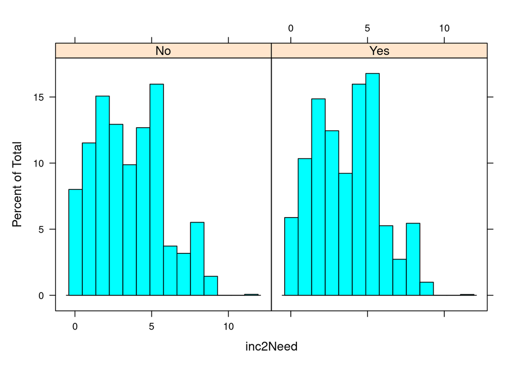

```
## [[1]]
##
##
## Table: smri_thick_cort.destrieux_g.front.inf.opercular
##
## |                       | Estimate| Std. Error|    95%L|    95%U|  p-val|
## |:----------------------|--------:|----------:|-------:|-------:|------:|
## |(Intercept)            |   0.1543|     0.1588| -0.1570|  0.4657| 0.3319|
## |race_ethnicityBlack    |   0.3529|     0.0766|  0.2027|  0.5031| 0.0000|
## |race_ethnicityHispanic |   0.1037|     0.0761| -0.0454|  0.2528| 0.1728|
## |race_ethnicityOther    |   0.1688|     0.0758|  0.0203|  0.3173| 0.0259|
## |race_ethnicityWhite    |   0.1658|     0.0735|  0.0218|  0.3099| 0.0241|
## |femaleyes              |   0.1230|     0.0146|  0.0945|  0.1515| 0.0000|
## |premature              |  -0.0017|     0.0364| -0.0730|  0.0696| 0.9630|
## |inc2Need               |   0.0015|     0.0040| -0.0064|  0.0094| 0.7153|
## |age                    |  -0.0036|     0.0010| -0.0055| -0.0017| 0.0002|
## |lateralityrh           |   0.0000|     0.0145| -0.0284|  0.0284| 1.0000|
## |premature:inc2Need     |   0.0003|     0.0084| -0.0160|  0.0167| 0.9692|
##
## [[2]]
##
##
## Table: smri_thick_cort.destrieux_g.front.inf.orbital
##
## |                       | Estimate| Std. Error|    95%L|    95%U|  p-val|
## |:----------------------|--------:|----------:|-------:|-------:|------:|
## |(Intercept)            |   0.3672|     0.1517|  0.0700|  0.6645| 0.0155|
## |race_ethnicityBlack    |   0.1327|     0.0798| -0.0238|  0.2892| 0.0966|
## |race_ethnicityHispanic |   0.1239|     0.0793| -0.0314|  0.2792| 0.1180|
## |race_ethnicityOther    |   0.1844|     0.0789|  0.0296|  0.3391| 0.0195|
## |race_ethnicityWhite    |   0.2471|     0.0766|  0.0971|  0.3972| 0.0013|
## |femaleyes              |   0.1114|     0.0152|  0.0816|  0.1411| 0.0000|
## |premature              |  -0.0278|     0.0379| -0.1022|  0.0465| 0.4635|
## |inc2Need               |   0.0058|     0.0042| -0.0024|  0.0140| 0.1667|
## |age                    |  -0.0053|     0.0010| -0.0074| -0.0033| 0.0000|
## |lateralityrh           |   0.0000|     0.0151| -0.0297|  0.0297| 1.0000|
## |premature:inc2Need     |  -0.0099|     0.0087| -0.0270|  0.0072| 0.2558|
##
## [[3]]
##
```

[output cut: 96 more lines]

```
## Table: smri_thick_cort.destrieux_s.temporal.transverse
##
## |                       | Estimate| Std. Error|    95%L|    95%U|  p-val|
## |:----------------------|--------:|----------:|-------:|-------:|------:|
## |(Intercept)            |   0.3297|     0.1482|  0.0393|  0.6201| 0.0261|
## |race_ethnicityBlack    |  -0.1109|     0.0803| -0.2683|  0.0465| 0.1672|
## |race_ethnicityHispanic |  -0.0471|     0.0798| -0.2034|  0.1092| 0.5549|
## |race_ethnicityOther    |  -0.0184|     0.0795| -0.1742|  0.1374| 0.8167|
## |race_ethnicityWhite    |   0.0183|     0.0770| -0.1327|  0.1692| 0.8126|
## |femaleyes              |   0.2328|     0.0153|  0.2028|  0.2629| 0.0000|
## |premature              |   0.0645|     0.0383| -0.0105|  0.1395| 0.0920|
## |inc2Need               |   0.0101|     0.0042|  0.0018|  0.0183| 0.0170|
## |age                    |  -0.0039|     0.0010| -0.0059| -0.0018| 0.0002|
## |lateralityrh           |   0.0000|     0.0153| -0.0300|  0.0300| 1.0000|
## |premature:inc2Need     |  -0.0220|     0.0088| -0.0392| -0.0048| 0.0123|
```